# R Notebook

Comparison of whole genome sequences provides a highly detailed view of how organisms are related to each other at the genetic level. I have considered a few criteria to compare the composition of the selected coronaviruses.

Oligonucleotide composition

GC content

Oligonucleotide composition

An oligonucleotide is a contiguous string of a small number of nucleotides. In computational terms, we define oligonucleotides as k-mers (words of size k). In this comparison, I have considered 3-mers (also known as trimers of trinucleotides) and their composition (trinucleotide composition). There are 32 (4³/2) distinct 3-mers. We obtain the normalised frequencies of each distinct trinucleotide by counting the number of occurrences of that trinucleotide and dividing by the total number of trinucleotides. We normalise these counts to avoid any unevenness caused due to different lengths of sequences.

Normalized frequency of kᵢ = Number of occurrences of kᵢ / total number of k-mers (where kᵢ is the iᵗʰ k-mer)

The oligonucleotide composition is conserved within microbial species and varies between species

GC content

GC content (or guanine-cytosine content) is the percentage of nucleotides in a sequence that are either guanine or cytosine.

GC content = (G + C) / (A + G + C + T) * 100

The GC content is also believed to vary between different species

Initialize the trimers and tetramers

```r
trimers <- c("AAA", "AAC", "AAG", "AAT", "ACA", "ACC", "ACG", "ACT", "AGA", "AGC", "AGG", "ATA", "ATC", "ATG", "CAA", "CAC", "CAG", "CCA","CCC","CCG","CGA","CGC","CTA","CTC","GAA","GAC","GCA","GCC","GGA","GTA","TAA","TCA")

tetramers <- c('AAAA','AAAC','AAAG','AAAT','AACA','AACC','AACG','AACT','AAGA','AAGC','AAGG','AAGT','AATA','AATC', 'AATG','AATT','ACAA','ACAC','ACAG','ACAT','ACCA','ACCC','ACCG','ACCT','ACGA','ACGC','ACGG','ACGT',
'ACTA','ACTC','ACTG','AGAA','AGAC','AGAG','AGAT','AGCA','AGCC','AGCG','AGCT','AGGA','AGGC','AGGG',
'AGTA','AGTC','AGTG','ATAA','ATAC','ATAG','ATAT','ATCA','ATCC','ATCG','ATGA','ATGC','ATGG','ATTA',
'ATTC','ATTG','CAAA','CAAC','CAAG','CACA','CACC','CACG','CAGA','CAGC','CAGG','CATA','CATC','CATG',
'CCAA','CCAC','CCAG','CCCA','CCCC','CCCG','CCGA','CCGC','CCGG','CCTA','CCTC','CGAA','CGAC','CGAG','CGCA','CGCC','CGCG','CGGA','CGGC','CGTA','CGTC','CTAA','CTAC','CTAG','CTCA','CTCC','CTGA','CTGC','CTTA','CTTC','GAAA','GAAC','GACA','GACC','GAGA','GAGC','GATA','GATC','GCAA','GCAC','GCCA','GCCC','GCGA','GCGC','GCTA','GGAA','GGAC','GGCA','GGCC','GGGA','GGTA','GTAA','GTAC','GTCA','GTGA','GTTA','TAAA','TACA','TAGA','TATA','TCAA','TCCA','TCGA','TGAA','TGCA','TTAA')
```

Define an oligo counter function

```r
oligo_counter <- function(gs_vector,oligo_collection,oligo_len){
    i <- oligo_len
    j <- 0
      counter <- c()
    len_gs_vector <- length(gs_vector)
    for (i in i:len_gs_vector)
        {     j <- 0
            temp_extract <- c()
            for ( j in 1:oligo_len-1)
                {
                    temp_extract <- c(temp_extract,gs_vector[c(i-j)])
                    #print(temp_extract)
                }

            curr_seq <- paste(temp_extract ,collapse='')
            #print(curr_seq)
            k <- 1
            # Merge cs into single string
            for (k in k:length(oligo_collection))
              {
                    if (curr_seq == oligo_collection[k])
                    {
                     counter <- c(counter, oligo_collection[k])
                }
                  }
        }

    a <- table(counter)
    Seq <- as.data.frame(a)

}
```

Read and vectorize sequences one by one

```r
library(seqinr)
covid <- read.fasta("datasets_fasta/cov2.fasta",forceDNAtolower = FALSE)
SARS <-  read.fasta("datasets_fasta/sars.fasta",forceDNAtolower = FALSE)
Mers <-  read.fasta("datasets_fasta/mers.fasta",forceDNAtolower = FALSE)
Bat_sars <-  read.fasta("datasets_fasta/BAT_SARS.fasta",forceDNAtolower = FALSE)
Bat_RaTG13 <- read.fasta("datasets_fasta/bat_RaTG13.txt",forceDNAtolower = FALSE)
hiv <- read.fasta("datasets_fasta/hiv2.fasta",forceDNAtolower = FALSE)
malaria <- read.fasta("datasets_fasta/malariae.fasta",forceDNAtolower = FALSE)
Pangolin <- read.fasta("datasets_fasta/pangolin.txt",forceDNAtolower = FALSE)
Bat_SL_CoVZC45 <- read.fasta("datasets_fasta/bat-SL-CoVZC45.txt",forceDNAtolower = FALSE)
```

Convert first sequence into vector

```r
covid_seq <- unlist(covid[[1]][1:length(covid[[1]])])
sars_seq <- unlist(SARS[[1]][1:length(SARS[[1]])])
mers_seq <- unlist(Mers[[1]][1:length(Mers[[1]])])
bat_seq <- unlist(Bat_sars[[1]][1:length(Bat_sars[[1]])])
bat_ratg13_seq<- unlist(Bat_RaTG13[[1]][1:length(Bat_RaTG13[[1]])])
hiv_seq <- unlist(hiv[[1]][1:length(hiv[[1]])])
malaria_seq <- unlist(malaria[[1]][1:length(malaria[[1]])])
Pangolin_seq <- unlist(Pangolin[[1]][1:length(Pangolin[[1]])])
Bat_SL_CoVZC45_seq <- unlist(Bat_SL_CoVZC45[[1]][1:length(Bat_SL_CoVZC45[[1]])])
```

Calculate trimer count of all

```r
covid_tri <- oligo_counter(covid_seq ,trimers,3)
sars_tri <- oligo_counter(sars_seq ,trimers,3)
mers_tri <- oligo_counter(mers_seq ,trimers,3)
bat_tri <- oligo_counter(bat_seq ,trimers,3)
bat_rat_tri <-oligo_counter(bat_ratg13_seq,trimers,3)
hiv_tri <- oligo_counter(hiv_seq ,trimers,3)
malaria_tri <- oligo_counter(malaria_seq ,trimers,3)
pangolin_tri<- oligo_counter(Pangolin_seq,trimers,3)
Bat_CovZC45_tri <- oligo_counter(Bat_SL_CoVZC45_seq,trimers,3)
```

Calculate tetramer count of all

```r
covid_tetra <- oligo_counter(covid_seq ,tetramers,4)
sars_tetra <- oligo_counter(sars_seq ,tetramers,4)
mers_tetra <- oligo_counter(mers_seq ,tetramers,4)
bat_tetra <- oligo_counter(bat_seq ,tetramers,4)
bat_rat_tetra <- oligo_counter(bat_ratg13_seq,tetramers,4)
hiv_tetra <- oligo_counter(hiv_seq ,tetramers,4)
malaria_tetra <- oligo_counter(malaria_seq ,tetramers,4)
pangolin_tetra <- oligo_counter(Bat_SL_CoVZC45_seq,tetramers,4)
Bat_CovZC45_tetra <- oligo_counter(Bat_SL_CoVZC45_seq,tetramers,4)
```

```r
tetramer_merge<- cbind(covid_tetra,sars_tetra$Freq,mers_tetra$Freq,bat_tetra$Freq,bat_rat_tetra$Freq,hiv_tetra$Freq,malaria_tetra$Freq,pangolin_tetra$Freq,Bat_CovZC45_tetra$Freq)
```

only for 5 genomes

```r
tetramer_merge_5<- data.frame(tetramers=tetramers,cov=tetramer_merge$cov,sars=tetramer_merge$sars,bat_ratg=tetramer_merge$bat_ratg,pangolin=tetramer_merge$pangolin,Bat_CovZC45=tetramer_merge$Bat_CovZC45)
```

Merge Trimers Rename columns and normalize Normalised freqeuncy of k? = Number of occurrences of k? / total number of k-mers

```r
trimers_merge <- cbind(covid_tri,sars_tri$Freq,mers_tri$Freq,bat_tri$Freq,bat_rat_tri$Freq,hiv_tri$Freq,malaria_tri$Freq,pangolin_tri$Freq,Bat_CovZC45_tri$Freq)

trimers_merge[,-1] = apply(trimers_merge[,-1],2,function(x){x/sum(x)})
names(trimers_merge)[1]<- "trimers"
names(trimers_merge)[2]<- "cov"
names(trimers_merge)[3]<- "sars"
names(trimers_merge)[4]<- "mers"
names(trimers_merge)[5]<- "bat"
names(trimers_merge)[6]<- "bat_ratg"
names(trimers_merge)[7]<- "hiv"
names(trimers_merge)[8]<- "mal"
names(trimers_merge)[9]<- "pangolin"
names(trimers_merge)[10]<- "Bat_CovZC45"
```

only for 5 genomes

```r
trimer_merge_5 <- data.frame(trimers=trimers,cov=trimers_merge$cov,sars=trimers_merge$sars,bat_ratg=trimers_merge$bat_rat,pangolin=trimers_merge$pangolin,Bat_CovZC45=trimers_merge$Bat_CovZC45)

library(reshape2)
plot<- melt(trimers_merge,id.var = "trimers")
plot5 <- melt(trimer_merge_5 ,id.var = "trimers")
plot_tetra <- melt(tetramer_merge,id.var = "tetramers")
plot_tetra_5 <- melt(tetramer_merge_5,id.var = "tetramers")
```

Line plot for trimers using package ggplot2

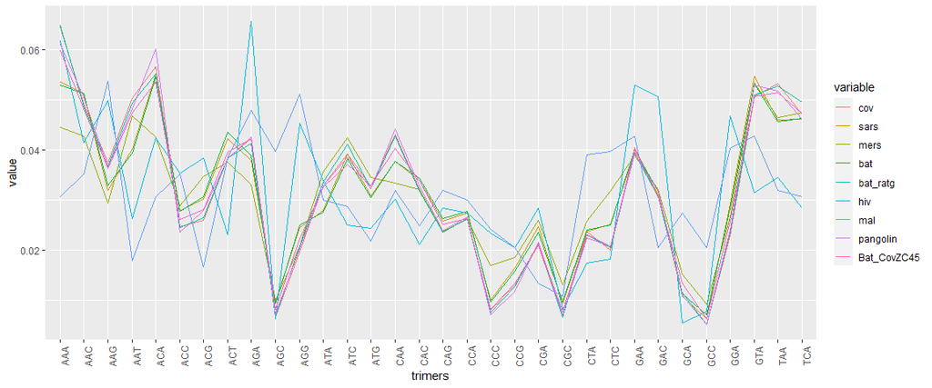

```r
library(ggplot2)
trimer_line_plot <- ggplot(plot, aes(x = trimers, y = value,group = variable, color = variable)) +
  geom_line()+ theme(axis.text.x = element_text(angle = 90))
trimer_line_plot
```

We can observe that COVID-19 and bat-RaTG13 show very similar trinucleotide composition patterns compared to SARS-CoV and Bat-CoV

Lets plot for only 5 closely related genomes

Plot the graphs for 5 genomes

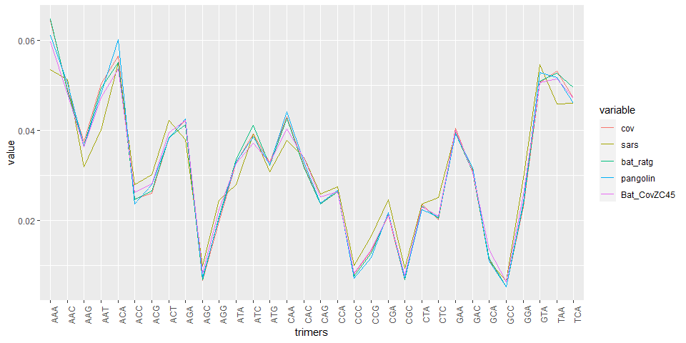

```r
trimer_line_plot5 <- ggplot(plot5, aes(x = trimers, y = value,group = variable, color = variable)) +
  geom_line()+ theme(axis.text.x = element_text(angle = 90))
trimer_line_plot5
```

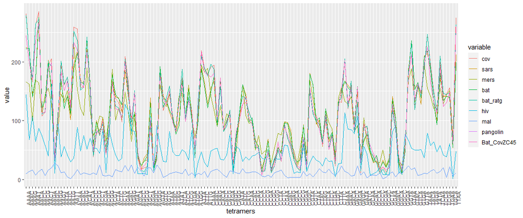

```r
tetra_line_plot <- ggplot(plot_tetra, aes(x = tetramers, y = value,group = variable, color = variable)) +
  geom_line()+ theme(axis.text.x = element_text(angle = 90))
tetra_line_plot
```

The tetranucleotide (4-mer or tetramer) composition patterns of the different coronavirus genomes. Similar trends to that of 3-mers can be seen

Lets plot only for 5 genomes Plot the graphs for 5 genomes

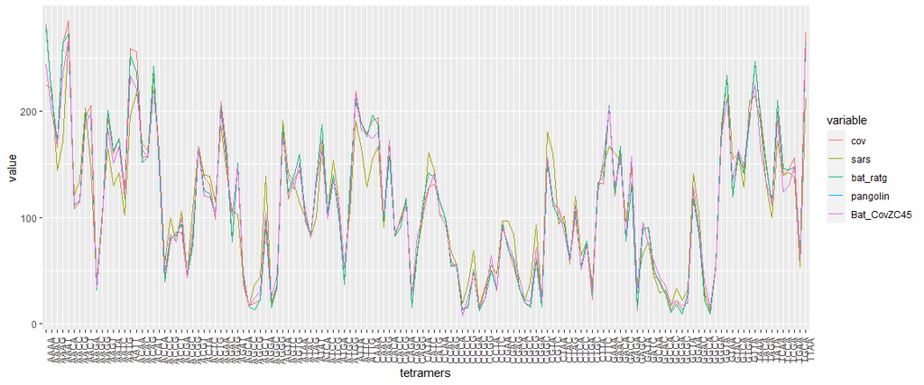

```r
tetra_line_plot5 <- ggplot(plot_tetra_5, aes(x = tetramers, y = value,group = variable, color = variable)) +
  geom_line()+ theme(axis.text.x = element_text(angle = 90))
tetra_line_plot5
```

GC content analysis

```r
covid_GC <- GC(covid_seq)
covid_GC
```

```
[1] 0.3797278
```

```r
sars_GC <- GC(sars_seq)
sars_GC
```

```
[1] 0.4076166
```

```r
mers_GC <- GC(mers_seq)
mers_GC
```

```
[1] 0.4123643
```

```r
bat_GC <- GC(bat_seq)
bat_GC
```

```
[1] 0.4098107
```

```r
bat_ratg13_GC <- GC(bat_ratg13_seq)
bat_ratg13_GC
```

```
[1] 0.3803718
```

```r
hiv_GC <- GC(hiv_seq)
hiv_GC
```

```
[1] 0.4566078
```

```r
malaria_GC <- GC(malaria_seq)
malaria_GC
```

```
[1] 0.4766111
```

```r
pangolin_GC <- GC(Pangolin_seq)
pangolin_GC
```

```
[1] 0.3819315
```

```r
Bat_CovZC45_GC <- GC(Bat_SL_CoVZC45_seq )
Bat_CovZC45_GC
```

```
[1] 0.3890343
```

According to the GC content values listed above, we can say that COVID-19 and bat-RaTG13,pangolin_Cov and Bat_CoVZC45 have very similar GC content of~37–38%. Plot for GC content

```r
GC_content <- c(covid_GC,sars_GC,mers_GC,bat_GC,bat_ratg13_GC,hiv_GC,malaria_GC,pangolin_GC,Bat_CovZC45_GC)
GC_df <- data.frame("Names"=character(9),"GC"=GC_content)
GC_df<- edit(GC_df)
GC_df
```

|  | Names | GC |
| --- | --- | --- |
| 1 | cov | 0.3797278 |
| 2 | sars | 0.4076166 |
| 3 | mers | 0.4123643 |
| 4 | bat | 0.4098107 |
| 5 | bat_ratg | 0.3803718 |
| 6 | hiv | 0.4566078 |
| 7 | malaria | 0.4766111 |
| 8 | pangolin | 0.3819315 |
| 9 | bat_covzc45 | 0.3890343 |

```r
NA
```

Plot a bar graph

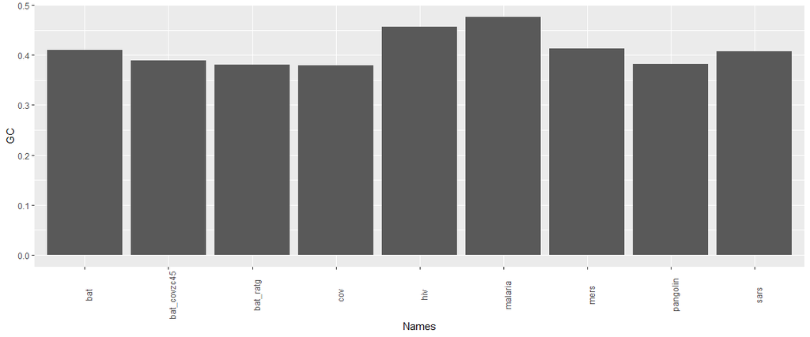

```r
plot_GC <- melt(GC_df,id.var = "Names")
plot_GC <- ggplot(GC_df, aes(x = Names, y = GC)) +
  geom_bar(stat = "identity")+ theme(axis.text.x = element_text(angle = 90))
plot_GC
```

Pairwise Sequence alignment First use a fixed substitution matrix The sequence alignment is a way of arranging the sequences of DNA/RNA or protein to identify regions of similarity that may be a consequence of functional, structural, or evolutionary relationships between the sequences.

Let’s align other genomes which have proved to be similar with the Covid-19 genome.

```r
covid_str <- paste(covid_seq , collapse="")
sars_str <- paste(sars_seq , collapse="")
ratg_str <- paste(bat_ratg13_seq , collapse="")
pangolin_str <- paste(Pangolin_seq, collapse="")
Bat_CoVZC45_str <- paste(Bat_SL_CoVZC45_seq ,collapse="")

library(Biostrings)
corona_dnastring <- DNAString(covid_str)
sars_dnastring <- DNAString(sars_str)
bat_ratg_dnastring <- DNAString(ratg_str)
pangolin_dnastring <- DNAString(pangolin_str)
Bat_CoVZC45_dnastring <- DNAString(Bat_CoVZC45_str)
```

Lets align the genomes using pairwise alignment The goal of pairwise sequence alignment is to establish a correspondence between the elements in a pair of sequences that share a common property, such as common ancestry or a common structural or functional role. Global alignment is used in cases where we have reason to believe that the sequences are related along their entire length Alignments can be scored with similarity measures. A higher score indicates a better alignment

```r
mat <- nucleotideSubstitutionMatrix(match = 1, mismatch = -1, baseOnly = TRUE)

corona_sars <-
    pairwiseAlignment(corona_dnastring,sars_dnastring, substitutionMatrix = mat,
                      gapOpening = 5, gapExtension = 2)
corona_sars
```

```
Global PairwiseAlignmentsSingleSubject (1 of 1)
pattern: ATTAAAGGTTTATACCTT...AAAAAAAAAAAAAAAAAA
subject: ATATTAGGTTTTTACCTA...AAAAAAAAA---------
score: 16961
```

```r
 corona_bat_ratg <-
    pairwiseAlignment(corona_dnastring,bat_ratg_dnastring, substitutionMatrix = mat,
                      gapOpening = 5, gapExtension = 2)
 corona_bat_ratg
```

```
Global PairwiseAlignmentsSingleSubject (1 of 1)
pattern: ATTAAAGGTTTATACCTT...AAAAAAAAAAAAAAAAAA
subject: ---------------CTT...AAAAA-------------
score: 27442
```

```r
corona_pangolin <-
    pairwiseAlignment(corona_dnastring,pangolin_dnastring, substitutionMatrix = mat,
                      gapOpening = 5, gapExtension = 2)
corona_pangolin
```

```
Global PairwiseAlignmentsSingleSubject (1 of 1)
pattern: ATTAAAGGTTTATACCTT...AAAAAAAAAAAAAAAAAA
subject: ------------------...------------------
score: 22912
```

```r
corona_bat_CoVZC45 <-
    pairwiseAlignment(corona_dnastring,Bat_CoVZC45_dnastring , substitutionMatrix = mat,
                      gapOpening = 5, gapExtension = 2)
corona_bat_CoVZC45
```

```
Global PairwiseAlignmentsSingleSubject (1 of 1)
pattern: ATTAAAGGTTTATACCTT...AAAAAAAAAAAAAAAAAA
subject: ATATTAGGTTTTTACCTT...AAAAAAAAAAAAAAAAAA
score: 22343
```

Perform a multiple sequence alignment Multiple sequence alignment is a tool used to study closely related genes or proteins in order to find their evolutionary relationships and to identify shared patterns among functionally or structurally related genes.

```r
DNA <- readDNAStringSet("D:/work/projects/R/genomic analysis/datasets_fasta/cov2.fasta", format="fasta",
               use.names=TRUE)
```

Perform a multiple sequence alignment using package msa

```r
library(msa)
msa <- msaClustalW(DNA,cluster="upgma", gapOpening=1,
                gapExtension= 1, maxiters= 16,
                substitutionMatrix="clustalw",type="dna",
                order=c("aligned", "input"), verbose=FALSE,
                help=FALSE)
```

Turn your alignment into a tree Convert the alignment for the seqinr package

```r
myseq <- msaConvert(msa, type="seqinr::alignment")
```

Generate a distance matrix using seqinr package

```r
d <- dist.alignment(myseq, "identity")
```

generate the tree with the ape package the nj() function allows neighbor-joining tree estimation

```r
library(ape)
myTree <- nj(d)
```

Plot the tree

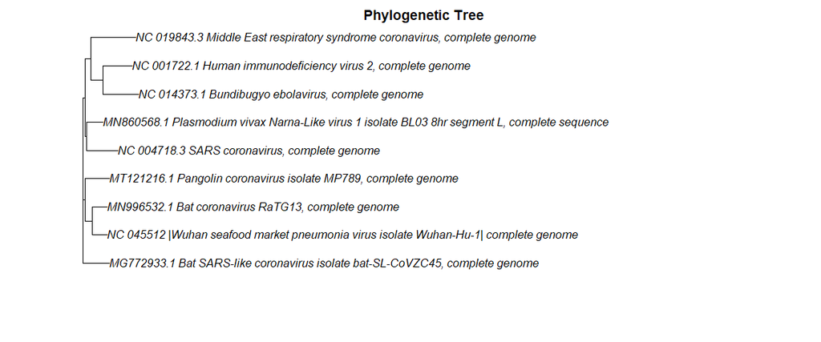

```r
plot(myTree, main="Phylogenetic Tree")
```

The findings here support the claims made in the recently published paper titled A new coronavirus associated with human respiratory disease in China where the authors state that the genome they have assembled is very closely related to the bat SARS-like coronavirus isolate SARSr-Ra-BatCoV RaTG13. The novel strain has indeed involved and changed since SARS-CoV was discovered in the year 2003.

Phylogenetic analysis showed that the SARS-CoV-2 is most closely related to that of SARSr-Ra-BatCoV RaTG13 followed by Pangolin-Cov and then Bat-SL-CoVZC45.

Pangolin-CoV is the second closest relative of SARS-CoV-2 behind RaTG13 as stated in Probable Pangolin Origin of SARS-CoV-2 Associated with the COVID-19 Outbreak

This finding suggests a distinct evolutionary origin for SARS-CoV-2, possibly as a result of recombination. SARS-CoV-2 might be a recombinant virus, with its genome backbone evolved from Yunnan bat virus–like SARSr-CoVs